# lab_4

Ofir Yosef and Ziv Parchi

```r
library(R.utils)
library(tidyverse)
library(dplyr)
library(tree)
library(rpart)
library(rpart.plot)
library(caret)
library(BBmisc)
library(Hmisc)
library(Epi)
library(pROC)
library(class)
library(e1071)
library(caTools)

#install.packages("ISLR")
```

```r
# modification of https://gist.github.com/brendano/39760
# automatically obtains data from the web
# creates two data frames, test and train
# labels are stored in the y variables of each data frame
# can easily train many models using formula `y ~ .` syntax

# download data from http://yann.lecun.com/exdb/mnist/
#download.file("http://yann.lecun.com/exdb/mnist/train-images-idx3-ubyte.gz","train-images-idx3-ubyte.gz")
#download.file("http://yann.lecun.com/exdb/mnist/train-labels-idx1-ubyte.gz","train-labels-idx1-ubyte.gz")
#download.file("http://yann.lecun.com/exdb/mnist/t10k-images-idx3-ubyte.gz","t10k-images-idx3-ubyte.gz")
#download.file("http://yann.lecun.com/exdb/mnist/t10k-labels-idx1-ubyte.gz","t10k-labels-idx1-ubyte.gz")

# gunzip the files
#R.utils::gunzip("train-images-idx3-ubyte.gz")
#R.utils::gunzip("train-labels-idx1-ubyte.gz")
#R.utils::gunzip("t10k-images-idx3-ubyte.gz")
#R.utils::gunzip("t10k-labels-idx1-ubyte.gz")

# helper function for visualization
show_digit = function(arr784, col = gray(12:1 / 12), ...) {
  image(matrix(as.matrix(arr784[-785]), nrow = 28)[, 28:1], col = col, ...)
}

# load image files
load_image_file = function(filename) {
  ret = list()
  f = file(filename, 'rb')
  readBin(f, 'integer', n = 1, size = 4, endian = 'big')
  n    = readBin(f, 'integer', n = 1, size = 4, endian = 'big')
  nrow = readBin(f, 'integer', n = 1, size = 4, endian = 'big')
  ncol = readBin(f, 'integer', n = 1, size = 4, endian = 'big')
  x = readBin(f, 'integer', n = n * nrow * ncol, size = 1, signed = FALSE)
  close(f)
  data.frame(matrix(x, ncol = nrow * ncol, byrow = TRUE))
}

# load label files
load_label_file = function(filename) {
  f = file(filename, 'rb')
  readBin(f, 'integer', n = 1, size = 4, endian = 'big')
  n = readBin(f, 'integer', n = 1, size = 4, endian = 'big')
  y = readBin(f, 'integer', n = n, size = 1, signed = FALSE)
  close(f)
  y
}

# load images
train = load_image_file("train-images-idx3-ubyte")
test  = load_image_file("t10k-images-idx3-ubyte")
# load labels
train$y = as.factor(load_label_file("train-labels-idx1-ubyte"))
test$y  = as.factor(load_label_file("t10k-labels-idx1-ubyte"))

# view test image
#show_digit(train[3, ])
```

```r
#filter only 3 and 8 digits

filter_train <- train %>% filter(y == 3 | y==8)
#sample only 4000
set.seed(1234)
filter_train <- as.data.frame(filter_train[sample(nrow(filter_train),4000),])
filter_test <- as.data.frame(test %>% filter(y == 3 | y==8))
```

Q.1:

```r
#2 classifiers- logistic and tree
#prepare the y to be logistic

glm_train <- filter_train
glm_train$y <- as.numeric(ifelse(test = filter_train$y ==3, yes = 1, no=0))
glm_test <- filter_test
glm_test$y <- as.numeric(ifelse(test = filter_test$y ==3, yes = 1, no=0))

#building logistic regression
logi_cla <- glm(y~., glm_train, family = "gaussian")
```

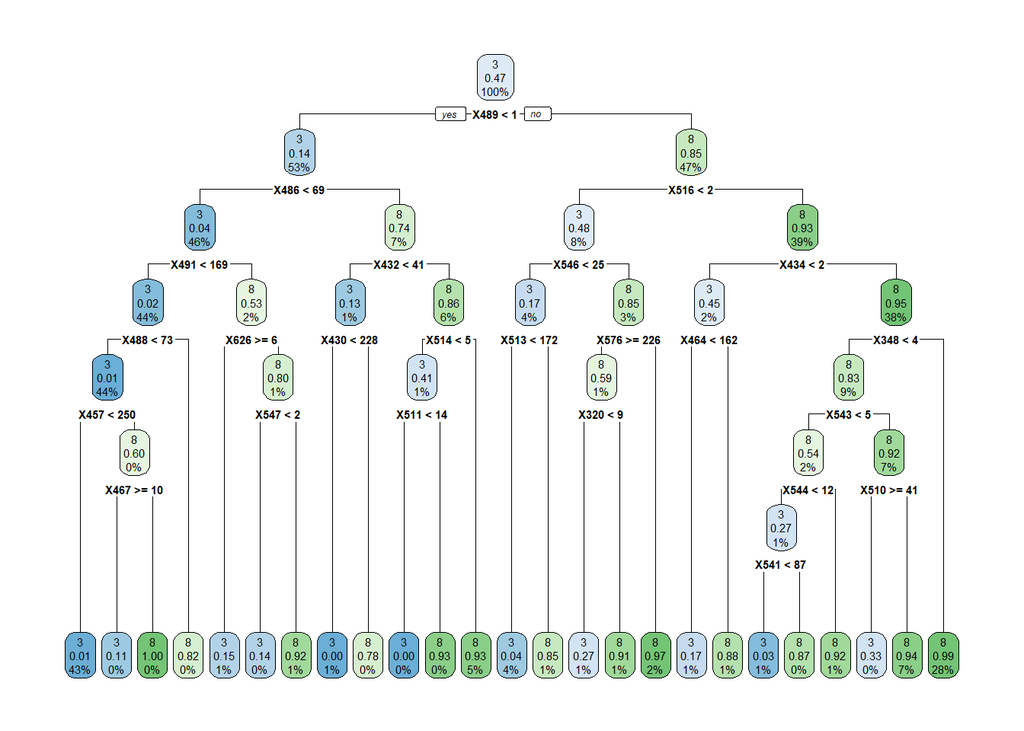

```r
#building a tree classifier model with many levels so we could get several thresholds from the roc function.
filter_train$y <- as.character(filter_train$y)
tree_cla <- rpart(y~., filter_train, method = "class",cp= 0.002)
rpart.plot(tree_cla)
```

```r
predicted_tree <- predict(tree_cla, filter_test)
```

Q.2:

```r
# write a function that calculate the confusion matrix, precision and recall
set.seed(1234)
confusion_function <- function(model, data_test,y_test, data_train,y_train){
  predictions <- predict(model, data_test)
  pred <- as.data.frame(ifelse(predictions > 0.5, yes = 3, no = 8))
  confusion_matrix <- table(pred[,1], y_test)
  confusion_matrix <- confusion_matrix[, colSums(confusion_matrix != 0) > 0]
  precision <- confusion_matrix[1]/(confusion_matrix[1]+confusion_matrix[3])
  recall <- confusion_matrix[1]/(confusion_matrix[1]+confusion_matrix[2])
  accuracy_test <- (confusion_matrix[1]+confusion_matrix[4])/(confusion_matrix[1]+confusion_matrix[4]+confusion_matrix[2]+confusion_matrix[3])

  predictions <- predict(model, data_train)
  pred <- as.data.frame(ifelse(predictions < 0.5, yes = 3, no = 8))
  confusion_matrix_2 <- table(pred[,1], y_train)
   confusion_matrix_2 <- confusion_matrix_2[, colSums(confusion_matrix_2 != 0) > 0]
  accuracy_train <- (confusion_matrix_2[1]+confusion_matrix_2[4])/(confusion_matrix_2[1]+confusion_matrix_2[4]+confusion_matrix_2[2]+confusion_matrix_2[3])

  print("The confusion matrix")
  print(as.table(confusion_matrix))
  paste("The precision", round(precision,3),"The recall", round(recall,3),"The accuracy test", round(accuracy_test,3),"The accuracy train", round(accuracy_train,3) )
}
#check the logist model
data_test <- filter_test[,-785]
data_train <- filter_train[,-785]

print("The logist model")
```

```
## [1] "The logist model"
```

```r
confusion_function(logi_cla,data_test, filter_test$y, data_train,glm_train$y)
```

```
## [1] "The confusion matrix"
##    y_test
##       3   8
##   3 964  45
##   8  46 929
```

```
## [1] "The precision 0.955 The recall 0.954 The accuracy test 0.954 The accuracy train 0.979"
```

```r
set.seed(1234)
#check the tree model
print("The tree model")
```

```
## [1] "The tree model"
```

```r
confusion_function(tree_cla,data_test, filter_test$y,data_train,glm_train$y)
```

```
## [1] "The confusion matrix"
##    y_test
##       3   8
##   3 962  26
##   8  48 948
```

```
## [1] "The precision 0.974 The recall 0.952 The accuracy test 0.963 The accuracy train 0.971"
```

Q.3:

```r
# creating the ROC function
roc_fun <- function(model,data_test,y_test){
h <- seq(0.01,0.99,0.01)
TPR <-c()
FPR <-c()
for(thre in h){
  predictions <- predict(model, data_test)
  pred <- as.data.frame(ifelse(predictions > thre, yes = 3, no = 8))
  confusion_matrix <- table(pred[,1], y_test)
  confusion_matrix <- confusion_matrix[, colSums(confusion_matrix != 0) > 0]
  TPR <- cbind(TPR,confusion_matrix[1]/(confusion_matrix[1]+confusion_matrix[2]))
 FPR <- cbind(FPR,confusion_matrix[3]/(confusion_matrix[3]+confusion_matrix[4]))
}
data_f <- data.frame(TPR=c(TPR),FPR=c(FPR), tresh = c(h))
data_f[is.na(data_f)] <- 0
return(data_f)
}
```

```r
 #creating a funtion that finds the best threshold.
find_tresh <- function(data){
  h_tresh <- c()
  h_best <- c()
  for (i in 1:99){
    h_tresh <- rbind(h_tresh,data$TPR[i]-data$FPR[i])
    h_best <- rbind(h_best,data$tresh[i])
  }
  join_data <- as.data.frame(cbind(h_tresh,h_best))
  maxi <- max(join_data$V1)
  h_trh <-join_data %>% filter(V1== maxi)
 print(h_trh)
}
```

```r
# Running ROC function for both models.
data_g <-roc_fun(logi_cla, data_test, filter_test$y)
data_t <-roc_fun(tree_cla, data_test, filter_test$y)

# Finding the best threshold for our models.
h_glm <- find_tresh(data_g)
```

```
##          V1   V2
## 1 0.9088784 0.46
```

```r
h_tree <- find_tresh(data_t)
```

```
##           V1   V2
## 1  0.9257812 0.23
## 2  0.9257812 0.24
## 3  0.9257812 0.25
## 4  0.9257812 0.26
## 5  0.9257812 0.27
## 6  0.9257812 0.28
## 7  0.9257812 0.29
## 8  0.9257812 0.30
## 9  0.9257812 0.31
## 10 0.9257812 0.32
## 11 0.9257812 0.33
## 12 0.9257812 0.34
## 13 0.9257812 0.35
## 14 0.9257812 0.36
```

[output cut: 30 more lines]

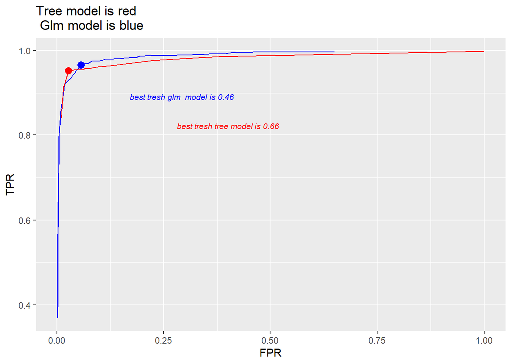

```r
hh_glm <- data_g %>% filter(tresh==0.46)
hh_tree <- data_t %>% filter(tresh==0.66)

sp2 <- ggplot() +
  geom_line(data = data_g, aes(x = FPR, y = TPR), color = "blue") + geom_line(data = data_t, aes(x = FPR, y = TPR), color = "red")+ggtitle("Tree model is red \n Glm model is blue")+ geom_point(data = hh_glm, aes(x = FPR, y = TPR), color = "blue",size = 3)+geom_point(data = hh_tree, aes(x = FPR, y = TPR), color = "red",size = 3)

library(grid)
# Create a text
grob <- grobTree(textGrob("best tresh glm  model is 0.46", x=0.2,  y=0.8, hjust=0,
  gp=gpar(col="blue", fontsize=8, fontface="italic")))
grob2 <- grobTree(textGrob("best tresh tree model is 0.66", x=0.3,  y=0.7, hjust=0,
  gp=gpar(col="red", fontsize=8, fontface="italic")))
# Plot
s <- sp2 + annotation_custom(grob)
s+annotation_custom(grob2)
```

*כמו שניתן לראות,הגרף של המודל של הרגרסיה הלוגיסטית נמצא מעל הגרף של המודל קלסיפיקציה של העצים. אם כן, יש יותר שטח מתחת לגרף הכחול מאשר מתחת לגרף האדום ולכן המודל הלוגיסטי טוב יותר.*

```r
set.seed(1234)
predictions <- predict(tree_cla, data_train)
pred <- as.data.frame(ifelse(predictions < 0.5, yes = "yes", no = "no"))
y_train <- as.data.frame(filter_train$y)
pred$y_train <- y_train$`filter_train$y`
pred$index <- row.names(y_train)

worng_clas_3 <- pred %>% filter(pred$`8` == "yes" & pred$y_train == 3)%>%  sample_n(2) # the index at the train data are 1120 and 3497

worng_clas_8 <- pred %>% filter(pred$`3` == "yes" & pred$y_train == 8)%>%  sample_n(2) # the index at the train data are 1513 and 3527

print("The true value is 3 the the predict value is 8")
```

```
## [1] "The true value is 3 the the predict value is 8"
```

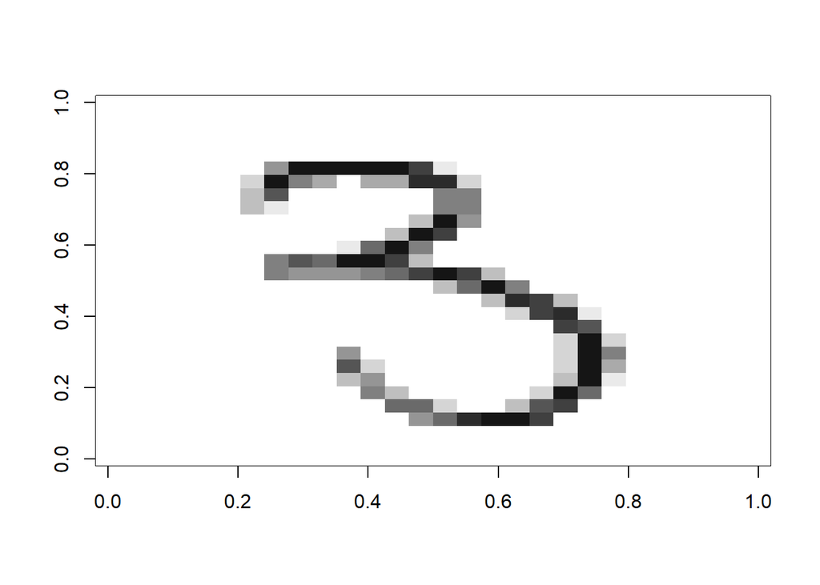

```r
show_digit(filter_train[1120,])
```

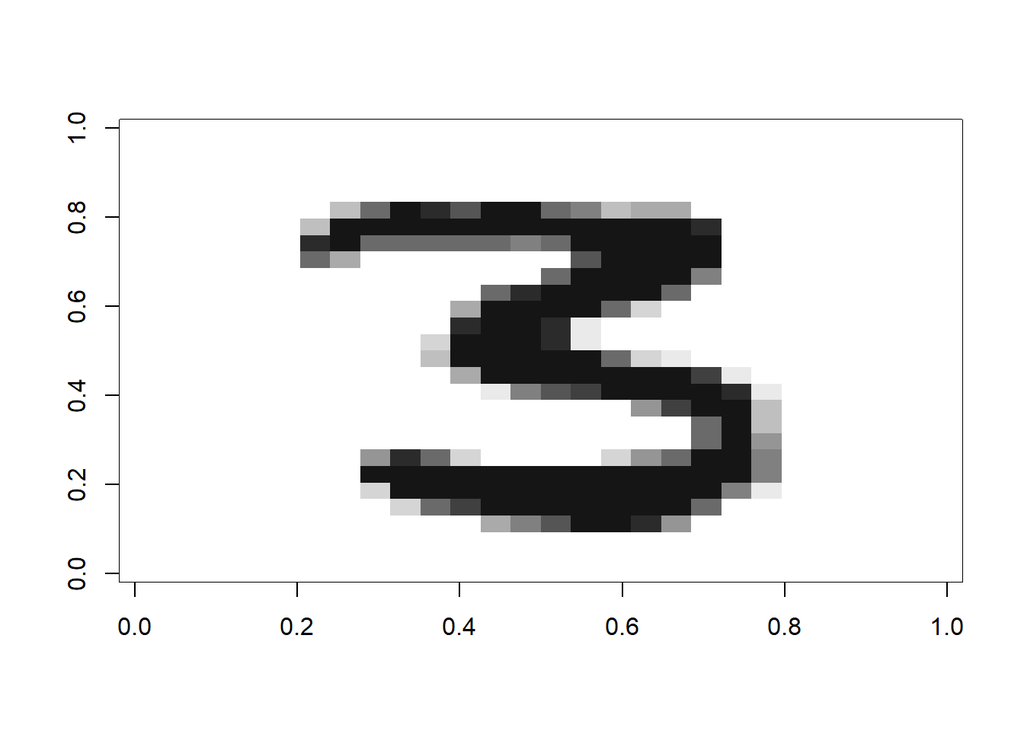

```r
show_digit(filter_train[3497,])
```

```r
print("The true value is 8 tns the predict value is 3")
```

```
## [1] "The true value is 8 tns the predict value is 3"
```

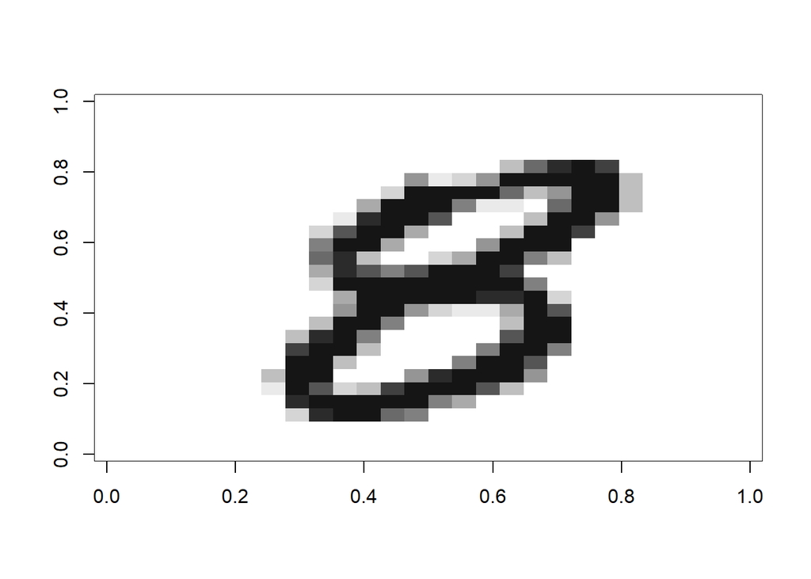

```r
show_digit(filter_train[3592,])
```

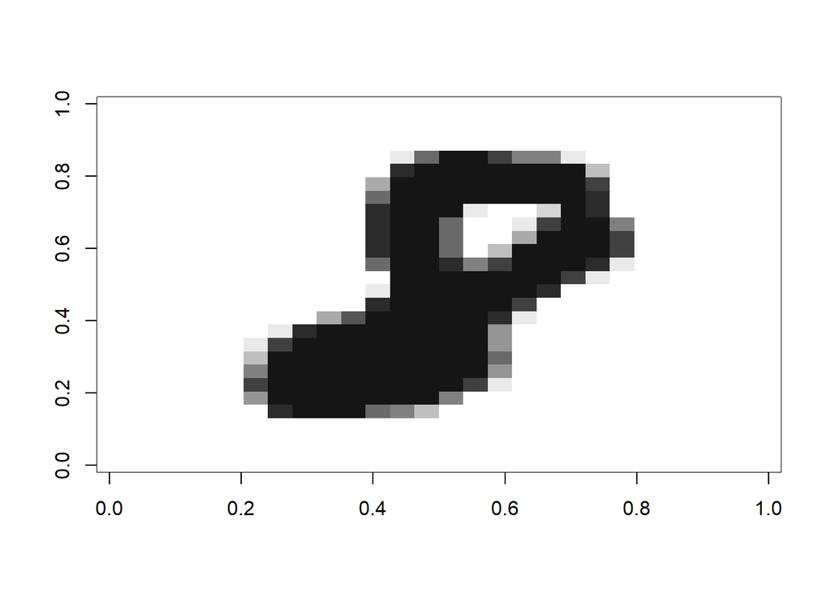

```r
show_digit(filter_train[380,])
```

*ניתן לראות בדוגמאות הללו כי הספרה אינה נמצאת באמצע התמונה, ייתכן שזו אחת הבעיות שגרמו לשגיאה בחיזוי מכיוון שהפיקסלים במקום שונה. בנוסף ניתן לראות כי חלק מהתמונות בעלות קו קהה יותר, כלומר יש יותר פיקסלים שחורים מאשר בכאלו עם קו דק, יתכן שזהו עוד גורם שגרם לחיזוי השגוי.*

Q.5:

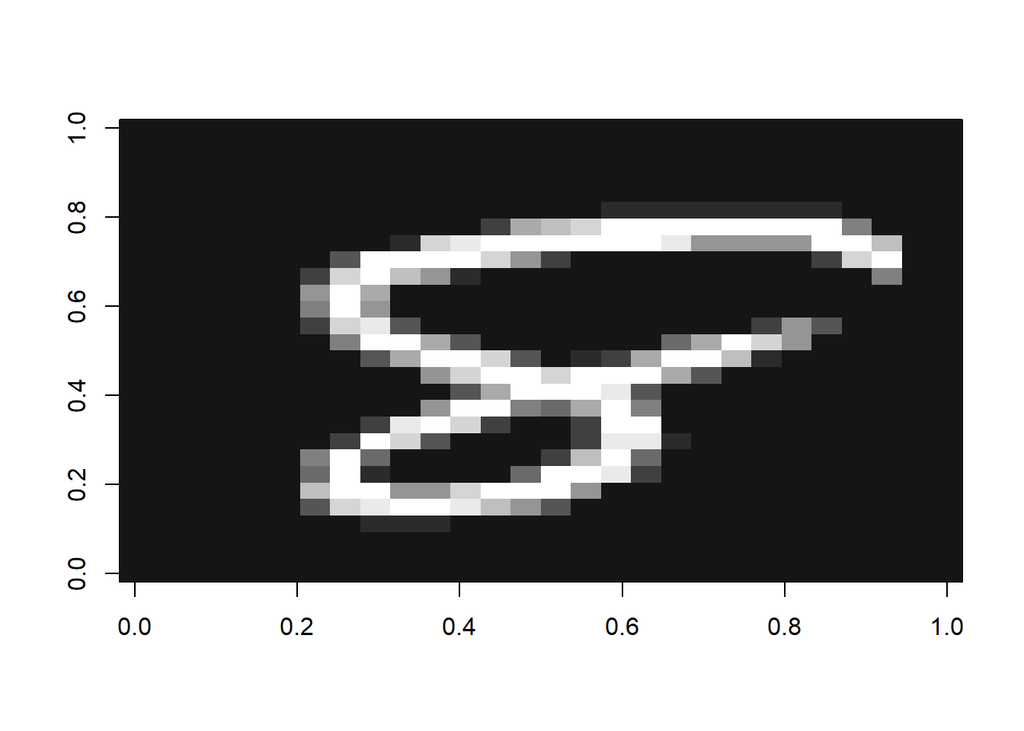

```r
# נחליף את הדאטה- אם בדאטה המקורית 1 סימל לבן ו255 שחור אז נחסר הכל ב255 בערך מוחלט וככה נקבל תמונה הפוכה
filter_train_black <-  data_train
filter_train_black <- abs(255- filter_train_black)
filter_train_black$y <- filter_train$y
filter_test_black <-  data_test
filter_test_black <- abs(255- filter_test_black)
filter_test_black$y <- filter_test$y

# show exmpale of the black data
show_digit(filter_train_black[3, ])
```

```r
#check cy the logist regression
data_test_b <- filter_test_black[,-785]
data_train_b <- filter_train_black[,-785]
glm_train_b <- filter_train_black
glm_train_b$y <- as.numeric(ifelse(test = filter_train_black$y ==3, yes = 1, no=0))
logi_cla_b <- glm(y~., glm_train_b, family = "gaussian")

print("The logist black model")
```

```
## [1] "The logist black model"
```

```r
confusion_function(logi_cla_b,data_test_b, filter_test_black$y,data_train_b,filter_train_black$y)
```

```
## [1] "The confusion matrix"
##    y_test
##       3   8
##   3 961  45
##   8  49 929
```

```
## [1] "The precision 0.955 The recall 0.951 The accuracy test 0.953 The accuracy train 0.021"
```

```r
print("The logist white model")
```

```
## [1] "The logist white model"
```

```r
confusion_function(logi_cla,data_test, filter_test$y, data_train,filter_train$y)
```

```
## [1] "The confusion matrix"
##    y_test
##       3   8
##   3 964  45
##   8  46 929
```

```
## [1] "The precision 0.955 The recall 0.954 The accuracy test 0.954 The accuracy train 0.021"
```

*It can be seen that the classifiers of the black model works almost the same like the white model.*

*נציין כי הרצנו בשאלה זו את הבדיקה על מודל הקלסיפיקציה הלוגיסטי ולא את המודל השני משום שהם יחסית דומים בתוצאות שלהם ולכן אין צורך להריץ את שניהם. נראה שהמודלים יוכלו לזהות את המספרים הללו בצורה טובה כמעט כמו המודל עבור התמונות ההפוכות.*